# Masters results

Michael Giordano

April 15, 2018

# true model

Here I am going to ignore the effects of skew, unbalance, and just look at relative bias and rmse for truemodels across sample sizes

## Figure 1

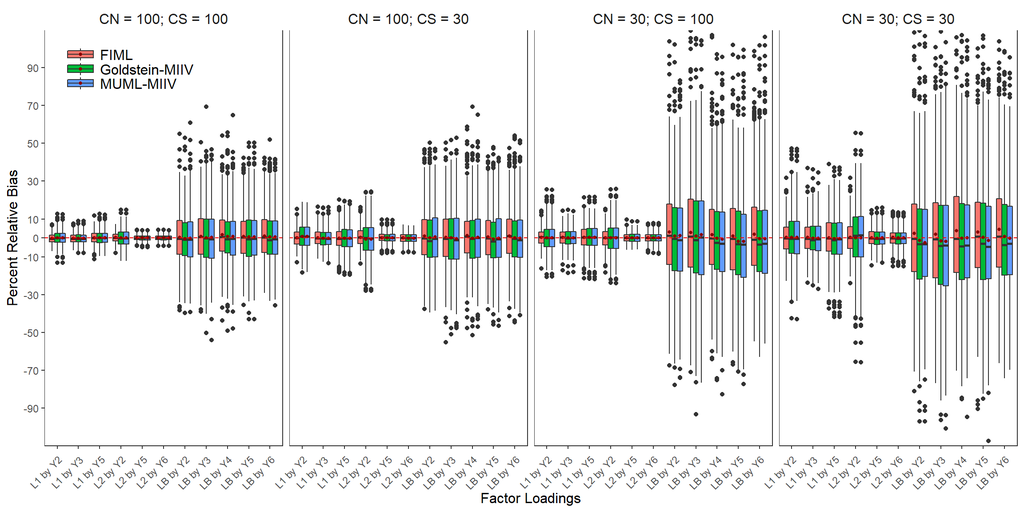

## Table 1: True Model Relative Bias

| parameter | CN = 100; CS = 100 FIML | CN = 100; CS = 100 Gold | CN = 100; CS = 100 MUML | CN = 100; CS = 30 FIML | CN = 100; CS = 30 Gold | CN = 100; CS = 30 MUML | CN = 30; CS = 100 FIML | CN = 30; CS = 100 Gold | CN = 30; CS = 100 MUML | CN = 30; CS = 30 FIML | CN = 30; CS = 30 Gold | CN = 30; CS = 30 MUML |
| --- | --- | --- | --- | --- | --- | --- | --- | --- | --- | --- | --- | --- |
| L1 by Y2 | -0.261 | -0.096 | -0.098 | 0.066 | 0.778 | 0.783 | 0.134 | 0.074 | 0.082 | 0.163 | 0.295 | 0.278 |
| L1 by Y3 | -0.185 | -0.267 | -0.261 | 0.102 | -0.199 | -0.206 | 0.161 | 0.053 | 0.053 | 0.297 | -0.249 | -0.197 |
| L1 by Y5 | 0.003 | 0.005 | 0.003 | -0.279 | -0.180 | -0.190 | 0.293 | 0.267 | 0.286 | -0.057 | -0.448 | -0.407 |
| L2 by Y2 | 0.156 | -0.080 | -0.075 | 0.318 | -0.626 | -0.632 | -0.017 | 0.040 | 0.032 | 0.274 | 0.017 | 0.023 |
| L2 by Y5 | -0.071 | -0.089 | -0.082 | 0.126 | 0.050 | 0.050 | 0.096 | 0.058 | 0.070 | -0.044 | -0.134 | -0.093 |
| L2 by Y6 | -0.049 | -0.085 | -0.069 | -0.031 | -0.138 | -0.109 | 0.036 | -0.037 | -0.025 | 0.172 | -0.105 | -0.047 |
| LB by Y2 | 0.290 | -0.476 | -0.179 | 0.880 | 0.102 | 0.490 | 3.022 | 0.964 | 1.111 | 2.426 | -1.315 | -2.461 |
| LB by Y3 | 0.710 | -0.031 | 0.221 | 0.225 | 0.037 | -0.471 | 2.916 | 0.935 | 1.542 | 1.848 | -1.657 | -1.876 |
| LB by Y4 | 1.595 | 0.621 | 0.600 | 1.113 | -0.114 | 0.294 | 1.560 | -0.145 | -0.667 | 3.888 | -0.238 | 0.074 |
| LB by Y5 | 0.690 | 0.432 | 0.563 | 0.409 | -0.745 | -0.197 | 0.976 | -1.767 | -1.875 | 2.966 | 0.258 | -1.462 |
| LB by Y6 | 0.958 | 0.510 | 0.523 | 0.967 | 0.004 | -0.259 | 1.784 | -0.531 | -0.386 | 4.412 | 0.802 | -0.238 |

## Table 2: True Model RMSE

| parameter | CN = 100; CS = 100 FIML | CN = 100; CS = 100 Gold | CN = 100; CS = 100 MUML | CN = 100; CS = 30 FIML | CN = 100; CS = 30 Gold | CN = 100; CS = 30 MUML | CN = 30; CS = 100 FIML | CN = 30; CS = 100 Gold | CN = 30; CS = 100 MUML | CN = 30; CS = 30 FIML | CN = 30; CS = 30 Gold | CN = 30; CS = 30 MUML |
| --- | --- | --- | --- | --- | --- | --- | --- | --- | --- | --- | --- | --- |
| L1 by Y2 | 0.020 | 0.028 | 0.028 | 0.035 | 0.057 | 0.057 | 0.036 | 0.056 | 0.056 | 0.069 | 0.106 | 0.106 |
| L1 by Y3 | 0.017 | 0.019 | 0.019 | 0.031 | 0.033 | 0.033 | 0.031 | 0.034 | 0.034 | 0.059 | 0.065 | 0.065 |
| L1 by Y5 | 0.010 | 0.011 | 0.011 | 0.019 | 0.020 | 0.020 | 0.018 | 0.020 | 0.020 | 0.034 | 0.037 | 0.037 |
| L2 by Y2 | 0.008 | 0.014 | 0.014 | 0.015 | 0.027 | 0.027 | 0.015 | 0.025 | 0.025 | 0.027 | 0.049 | 0.049 |
| L2 by Y5 | 0.012 | 0.012 | 0.012 | 0.021 | 0.021 | 0.021 | 0.019 | 0.020 | 0.020 | 0.037 | 0.038 | 0.038 |
| L2 by Y6 | 0.010 | 0.010 | 0.010 | 0.018 | 0.018 | 0.018 | 0.018 | 0.018 | 0.018 | 0.032 | 0.032 | 0.032 |
| LB by Y2 | 0.090 | 0.094 | 0.097 | 0.100 | 0.106 | 0.109 | 0.187 | 0.194 | 0.195 | 0.215 | 0.225 | 0.315 |
| LB by Y3 | 0.083 | 0.090 | 0.090 | 0.092 | 0.099 | 0.099 | 0.171 | 0.180 | 0.180 | 0.204 | 0.213 | 0.209 |
| LB by Y4 | 0.106 | 0.113 | 0.112 | 0.113 | 0.123 | 0.126 | 0.198 | 0.200 | 0.208 | 0.264 | 0.264 | 0.267 |
| LB by Y5 | 0.089 | 0.099 | 0.098 | 0.100 | 0.111 | 0.109 | 0.189 | 0.194 | 0.196 | 0.225 | 0.280 | 0.233 |
| LB by Y6 | 0.102 | 0.108 | 0.108 | 0.112 | 0.123 | 0.123 | 0.192 | 0.201 | 0.217 | 0.243 | 0.251 | 0.241 |

## Table 3: True Model Standard Errors table (Emp_sd (meanSE))

| parameter | CN = 100; CS = 100 FIML | CN = 100; CS = 100 Gold | CN = 100; CS = 100 MUML | CN = 100; CS = 30 FIML | CN = 100; CS = 30 Gold | CN = 100; CS = 30 MUML | CN = 30; CS = 100 FIML | CN = 30; CS = 100 Gold | CN = 30; CS = 100 MUML | CN = 30; CS = 30 FIML | CN = 30; CS = 30 Gold | CN = 30; CS = 30 MUML |
| --- | --- | --- | --- | --- | --- | --- | --- | --- | --- | --- | --- | --- |
| L1 by Y2 | 0.02 (0.02) | 0.03 (0.02) | 0.03 (0.03) | 0.03 (0.04) | 0.06 (0.04) | 0.06 (0.06) | 0.04 (0.04) | 0.06 (0.04) | 0.06 (0.05) | 0.07 (0.06) | 0.11 (0.07) | 0.11 (0.10) |
| L1 by Y3 | 0.02 (0.02) | 0.02 (0.01) | 0.02 (0.02) | 0.03 (0.03) | 0.03 (0.02) | 0.03 (0.03) | 0.03 (0.03) | 0.03 (0.02) | 0.03 (0.03) | 0.06 (0.06) | 0.07 (0.04) | 0.06 (0.06) |
| L1 by Y5 | 0.01 (0.01) | 0.01 (0.01) | 0.01 (0.01) | 0.02 (0.02) | 0.02 (0.01) | 0.02 (0.02) | 0.02 (0.02) | 0.02 (0.01) | 0.02 (0.02) | 0.03 (0.03) | 0.04 (0.03) | 0.04 (0.04) |
| L2 by Y2 | 0.01 (0.01) | 0.01 (0.01) | 0.01 (0.01) | 0.02 (0.01) | 0.03 (0.02) | 0.03 (0.03) | 0.02 (0.01) | 0.03 (0.02) | 0.03 (0.03) | 0.03 (0.03) | 0.05 (0.04) | 0.05 (0.05) |
| L2 by Y5 | 0.01 (0.01) | 0.01 (0.01) | 0.01 (0.01) | 0.02 (0.02) | 0.02 (0.02) | 0.02 (0.02) | 0.02 (0.02) | 0.02 (0.02) | 0.02 (0.02) | 0.04 (0.04) | 0.04 (0.03) | 0.04 (0.04) |
| L2 by Y6 | 0.01 (0.01) | 0.01 (0.01) | 0.01 (0.01) | 0.02 (0.02) | 0.02 (0.01) | 0.02 (0.02) | 0.02 (0.02) | 0.02 (0.01) | 0.02 (0.02) | 0.03 (0.03) | 0.03 (0.02) | 0.03 (0.03) |
| LB by Y2 | 0.09 (0.09) | 0.09 (0.09) | 0.10 (0.09) | 0.10 (0.10) | 0.11 (0.09) | 0.11 (0.09) | 0.19 (0.17) | 0.19 (0.17) | 0.19 (0.17) | 0.21 (0.20) | 0.23 (0.17) | 0.31 (0.18) |
| LB by Y3 | 0.08 (0.08) | 0.09 (0.09) | 0.09 (0.09) | 0.09 (0.09) | 0.10 (0.09) | 0.10 (0.09) | 0.17 (0.16) | 0.18 (0.16) | 0.18 (0.16) | 0.20 (0.18) | 0.21 (0.16) | 0.21 (0.16) |
| LB by Y4 | 0.11 (0.10) | 0.11 (0.10) | 0.11 (0.10) | 0.11 (0.12) | 0.12 (0.10) | 0.13 (0.10) | 0.20 (0.18) | 0.20 (0.18) | 0.21 (0.18) | 0.26 (0.24) | 0.26 (0.18) | 0.27 (0.18) |
| LB by Y5 | 0.09 (0.09) | 0.10 (0.09) | 0.10 (0.09) | 0.10 (0.10) | 0.11 (0.09) | 0.11 (0.09) | 0.19 (0.17) | 0.19 (0.17) | 0.20 (0.17) | 0.22 (0.21) | 0.28 (0.19) | 0.23 (0.18) |
| LB by Y6 | 0.10 (0.10) | 0.11 (0.10) | 0.11 (0.10) | 0.11 (0.11) | 0.12 (0.10) | 0.12 (0.10) | 0.19 (0.19) | 0.20 (0.18) | 0.22 (0.18) | 0.24 (0.23) | 0.25 (0.19) | 0.24 (0.19) |

# MisSpecW1

## Figure 2 : Misspecification #1

```
## Warning: Removed 7210 rows containing non-finite values (stat_boxplot).
```

```
## Warning: Removed 7210 rows containing non-finite values (stat_summary).
```

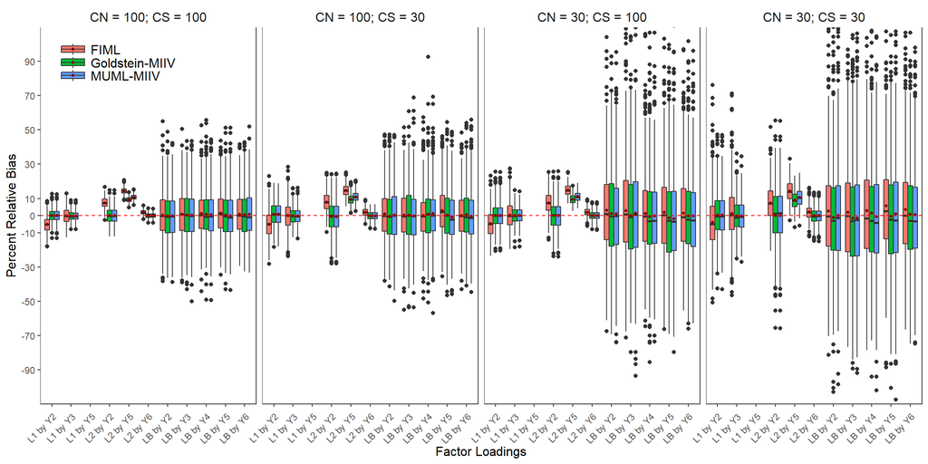

## Table 4: Bias table

| parameter | CN = 100; CS = 100 FIML | CN = 100; CS = 100 Gold | CN = 100; CS = 100 MUML | CN = 100; CS = 30 FIML | CN = 100; CS = 30 Gold | CN = 100; CS = 30 MUML | CN = 30; CS = 100 FIML | CN = 30; CS = 100 Gold | CN = 30; CS = 100 MUML | CN = 30; CS = 30 FIML | CN = 30; CS = 30 Gold | CN = 30; CS = 30 MUML |
| --- | --- | --- | --- | --- | --- | --- | --- | --- | --- | --- | --- | --- |
| L1 by Y2 | -5.271 | -0.096 | -0.098 | -5.155 | 0.778 | 0.783 | -4.704 | 0.074 | 0.082 | -3.890 | 0.295 | 0.278 |
| L1 by Y3 | -0.197 | -0.267 | -0.261 | -0.092 | -0.199 | -0.206 | 0.345 | 0.053 | 0.053 | 1.167 | -0.249 | -0.197 |
| L1 by Y5 | NaN | NaN | NaN | NaN | NaN | NaN | NaN | NaN | NaN | NaN | NaN | NaN |
| L2 by Y2 | 7.408 | -0.080 | -0.075 | 7.739 | -0.626 | -0.632 | 7.306 | 0.040 | 0.032 | 7.405 | 0.017 | 0.023 |
| L2 by Y5 | 14.324 | 9.197 | 10.690 | 14.613 | 9.324 | 10.832 | 14.762 | 9.456 | 10.965 | 14.409 | 8.972 | 10.533 |
| L2 by Y6 | 1.943 | -0.085 | -0.069 | 1.973 | -0.138 | -0.109 | 1.993 | -0.037 | -0.025 | 2.061 | -0.105 | -0.047 |
| LB by Y2 | 0.292 | -0.113 | -0.292 | 0.917 | -0.343 | 0.314 | 3.013 | 1.255 | 0.866 | 2.485 | -1.130 | 0.024 |
| LB by Y3 | 0.705 | 0.147 | 0.259 | 0.271 | 0.229 | -0.315 | 2.909 | 0.063 | 1.482 | 1.817 | -1.700 | -1.384 |
| LB by Y4 | 1.232 | 0.763 | 0.408 | 0.052 | 0.700 | 1.081 | 1.151 | -0.619 | -0.168 | 2.774 | 1.377 | -0.736 |
| LB by Y5 | 1.446 | 0.238 | -0.136 | 2.844 | 0.155 | -0.891 | 1.824 | -1.401 | -1.796 | 5.648 | -0.464 | 1.013 |
| LB by Y6 | 0.683 | 0.532 | 0.828 | 0.082 | 0.383 | -0.551 | 1.499 | -0.315 | -0.335 | 3.528 | 0.749 | 0.372 |

## Table 5: RMSE

| parameter | CN = 100; CS = 100 FIML | CN = 100; CS = 100 Gold | CN = 100; CS = 100 MUML | CN = 100; CS = 30 FIML | CN = 100; CS = 30 Gold | CN = 100; CS = 30 MUML | CN = 30; CS = 100 FIML | CN = 30; CS = 100 Gold | CN = 30; CS = 100 MUML | CN = 30; CS = 30 FIML | CN = 30; CS = 30 Gold | CN = 30; CS = 30 MUML |
| --- | --- | --- | --- | --- | --- | --- | --- | --- | --- | --- | --- | --- |
| L1 by Y2 | 0.055 | 0.028 | 0.028 | 0.076 | 0.057 | 0.057 | 0.075 | 0.056 | 0.056 | 0.134 | 0.106 | 0.106 |
| L1 by Y3 | 0.032 | 0.019 | 0.019 | 0.056 | 0.033 | 0.033 | 0.056 | 0.034 | 0.034 | 0.113 | 0.065 | 0.065 |
| L1 by Y5 | 0.000 | 0.000 | 0.000 | 0.000 | 0.000 | 0.000 | 0.000 | 0.000 | 0.000 | 0.000 | 0.000 | 0.000 |
| L2 by Y2 | 0.024 | 0.014 | 0.014 | 0.029 | 0.027 | 0.027 | 0.029 | 0.025 | 0.025 | 0.039 | 0.049 | 0.049 |
| L2 by Y5 | 0.116 | 0.075 | 0.086 | 0.120 | 0.078 | 0.090 | 0.121 | 0.079 | 0.090 | 0.125 | 0.082 | 0.094 |
| L2 by Y6 | 0.016 | 0.010 | 0.010 | 0.022 | 0.018 | 0.018 | 0.022 | 0.018 | 0.018 | 0.034 | 0.032 | 0.032 |
| LB by Y2 | 0.090 | 0.095 | 0.095 | 0.100 | 0.105 | 0.110 | 0.186 | 0.199 | 0.193 | 0.217 | 0.228 | 0.222 |
| LB by Y3 | 0.083 | 0.086 | 0.088 | 0.092 | 0.102 | 0.100 | 0.171 | 0.175 | 0.183 | 0.204 | 0.206 | 0.238 |
| LB by Y4 | 0.105 | 0.114 | 0.113 | 0.113 | 0.128 | 0.126 | 0.198 | 0.204 | 0.198 | 0.265 | 0.299 | 0.268 |
| LB by Y5 | 0.090 | 0.096 | 0.096 | 0.103 | 0.112 | 0.112 | 0.190 | 0.201 | 0.196 | 0.231 | 0.223 | 0.278 |
| LB by Y6 | 0.102 | 0.109 | 0.109 | 0.112 | 0.122 | 0.123 | 0.192 | 0.200 | 0.207 | 0.245 | 0.262 | 0.248 |

## Table 6: Standard Errors (Emp_sd (meanSE))

| parameter | CN = 100; CS = 100 FIML | CN = 100; CS = 100 Gold | CN = 100; CS = 100 MUML | CN = 100; CS = 30 FIML | CN = 100; CS = 30 Gold | CN = 100; CS = 30 MUML | CN = 30; CS = 100 FIML | CN = 30; CS = 100 Gold | CN = 30; CS = 100 MUML | CN = 30; CS = 30 FIML | CN = 30; CS = 30 Gold | CN = 30; CS = 30 MUML |
| --- | --- | --- | --- | --- | --- | --- | --- | --- | --- | --- | --- | --- |
| L1 by Y2 | 0.04 (0.04) | 0.03 (0.02) | 0.03 (0.03) | 0.06 (0.07) | 0.06 (0.04) | 0.06 (0.06) | 0.06 (0.06) | 0.06 (0.04) | 0.06 (0.05) | 0.13 (0.12) | 0.11 (0.07) | 0.11 (0.10) |
| L1 by Y3 | 0.03 (0.03) | 0.02 (0.01) | 0.02 (0.02) | 0.06 (0.06) | 0.03 (0.02) | 0.03 (0.03) | 0.06 (0.06) | 0.03 (0.02) | 0.03 (0.03) | 0.11 (0.11) | 0.07 (0.04) | 0.06 (0.06) |
| L1 by Y5 | NaN (NaN) | NaN (NaN) | NaN (NaN) | NaN (NaN) | NaN (NaN) | NaN (NaN) | NaN (NaN) | NaN (NaN) | NaN (NaN) | NaN (NaN) | NaN (NaN) | NaN (NaN) |
| L2 by Y2 | 0.01 (0.01) | 0.01 (0.01) | 0.01 (0.01) | 0.02 (0.02) | 0.03 (0.02) | 0.03 (0.03) | 0.02 (0.02) | 0.03 (0.02) | 0.03 (0.03) | 0.03 (0.03) | 0.05 (0.04) | 0.05 (0.05) |
| L2 by Y5 | 0.01 (0.01) | 0.01 (0.01) | 0.01 (0.01) | 0.03 (0.03) | 0.02 (0.02) | 0.02 (0.02) | 0.03 (0.03) | 0.02 (0.02) | 0.02 (0.02) | 0.05 (0.05) | 0.04 (0.03) | 0.04 (0.04) |
| L2 by Y6 | 0.01 (0.01) | 0.01 (0.01) | 0.01 (0.01) | 0.02 (0.02) | 0.02 (0.01) | 0.02 (0.02) | 0.02 (0.02) | 0.02 (0.01) | 0.02 (0.02) | 0.03 (0.03) | 0.03 (0.02) | 0.03 (0.03) |
| LB by Y2 | 0.09 (0.09) | 0.09 (0.09) | 0.09 (0.09) | 0.10 (0.10) | 0.10 (0.09) | 0.11 (0.09) | 0.19 (0.17) | 0.20 (0.17) | 0.19 (0.17) | 0.22 (0.20) | 0.23 (0.18) | 0.22 (0.17) |
| LB by Y3 | 0.08 (0.08) | 0.09 (0.09) | 0.09 (0.09) | 0.09 (0.09) | 0.10 (0.09) | 0.10 (0.09) | 0.17 (0.16) | 0.17 (0.16) | 0.18 (0.16) | 0.20 (0.19) | 0.21 (0.16) | 0.24 (0.17) |
| LB by Y4 | 0.11 (0.10) | 0.11 (0.10) | 0.11 (0.10) | 0.11 (0.12) | 0.13 (0.10) | 0.13 (0.10) | 0.20 (0.18) | 0.20 (0.18) | 0.20 (0.18) | 0.26 (0.24) | 0.30 (0.20) | 0.27 (0.18) |
| LB by Y5 | 0.09 (0.09) | 0.10 (0.09) | 0.10 (0.09) | 0.10 (0.10) | 0.11 (0.09) | 0.11 (0.09) | 0.19 (0.17) | 0.20 (0.17) | 0.20 (0.17) | 0.23 (0.21) | 0.22 (0.18) | 0.28 (0.19) |
| LB by Y6 | 0.10 (0.10) | 0.11 (0.10) | 0.11 (0.10) | 0.11 (0.11) | 0.12 (0.10) | 0.12 (0.10) | 0.19 (0.19) | 0.20 (0.18) | 0.21 (0.18) | 0.24 (0.23) | 0.26 (0.19) | 0.25 (0.19) |

# MisSpecW2

## Figure 3 : Misspecification #2

```
## Warning: Removed 7210 rows containing non-finite values (stat_boxplot).
```

```
## Warning: Removed 7210 rows containing non-finite values (stat_summary).
```

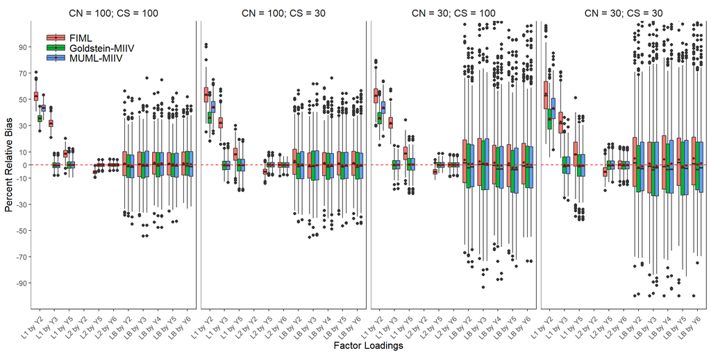

## Table 7: bias

| parameter | CN = 100; CS = 100 FIML | CN = 100; CS = 100 Gold | CN = 100; CS = 100 MUML | CN = 100; CS = 30 FIML | CN = 100; CS = 30 Gold | CN = 100; CS = 30 MUML | CN = 30; CS = 100 FIML | CN = 30; CS = 100 Gold | CN = 30; CS = 100 MUML | CN = 30; CS = 30 FIML | CN = 30; CS = 30 Gold | CN = 30; CS = 30 MUML |
| --- | --- | --- | --- | --- | --- | --- | --- | --- | --- | --- | --- | --- |
| L1 by Y2 | 52.533 | 35.412 | 43.435 | 53.570 | 36.028 | 44.137 | 52.941 | 35.711 | 43.652 | 54.233 | 35.264 | 43.295 |
| L1 by Y3 | 31.706 | -0.267 | -0.261 | 32.303 | -0.199 | -0.206 | 31.915 | 0.053 | 0.053 | 32.896 | -0.249 | -0.197 |
| L1 by Y5 | 8.526 | 0.005 | 0.003 | 8.072 | -0.180 | -0.190 | 8.723 | 0.267 | 0.286 | 7.969 | -0.448 | -0.407 |
| L2 by Y2 | NaN | NaN | NaN | NaN | NaN | NaN | NaN | NaN | NaN | NaN | NaN | NaN |
| L2 by Y5 | -5.455 | -0.089 | -0.082 | -5.229 | 0.050 | 0.050 | -5.276 | 0.058 | 0.070 | -5.268 | -0.134 | -0.093 |
| L2 by Y6 | -0.027 | -0.085 | -0.069 | -0.005 | -0.138 | -0.109 | 0.024 | -0.037 | -0.025 | 0.163 | -0.105 | -0.047 |
| LB by Y2 | 0.951 | -0.486 | -0.651 | 3.002 | 0.152 | 0.309 | 3.766 | 0.747 | 0.670 | 4.893 | -2.125 | -1.188 |
| LB by Y3 | 0.506 | 0.053 | 0.003 | -0.337 | -0.722 | -0.244 | 2.669 | 0.842 | 0.928 | 0.865 | -1.764 | -1.281 |
| LB by Y4 | 1.656 | 0.540 | 1.140 | 1.310 | -0.301 | -0.058 | 1.618 | -0.560 | -0.413 | 4.236 | -0.655 | 0.959 |
| LB by Y5 | 0.951 | 0.532 | 0.125 | 1.267 | -0.396 | -0.154 | 1.244 | -2.099 | -2.066 | 3.981 | -1.218 | -0.384 |
| LB by Y6 | 1.097 | 1.069 | 0.556 | 1.424 | -0.263 | -0.066 | 1.938 | 0.181 | 0.056 | 5.056 | 0.302 | 1.081 |

## Table 8: RMSE table

| parameter | CN = 100; CS = 100 FIML | CN = 100; CS = 100 Gold | CN = 100; CS = 100 MUML | CN = 100; CS = 30 FIML | CN = 100; CS = 30 Gold | CN = 100; CS = 30 MUML | CN = 30; CS = 100 FIML | CN = 30; CS = 100 Gold | CN = 30; CS = 100 MUML | CN = 30; CS = 30 FIML | CN = 30; CS = 30 Gold | CN = 30; CS = 30 MUML |
| --- | --- | --- | --- | --- | --- | --- | --- | --- | --- | --- | --- | --- |
| L1 by Y2 | 0.422 | 0.285 | 0.349 | 0.434 | 0.293 | 0.357 | 0.429 | 0.290 | 0.353 | 0.452 | 0.296 | 0.359 |
| L1 by Y3 | 0.223 | 0.019 | 0.019 | 0.230 | 0.033 | 0.033 | 0.227 | 0.034 | 0.034 | 0.245 | 0.065 | 0.065 |
| L1 by Y5 | 0.028 | 0.011 | 0.011 | 0.032 | 0.020 | 0.020 | 0.034 | 0.020 | 0.020 | 0.046 | 0.037 | 0.037 |
| L2 by Y2 | 0.000 | 0.000 | 0.000 | 0.000 | 0.000 | 0.000 | 0.000 | 0.000 | 0.000 | 0.000 | 0.000 | 0.000 |
| L2 by Y5 | 0.045 | 0.012 | 0.012 | 0.047 | 0.021 | 0.021 | 0.047 | 0.020 | 0.020 | 0.058 | 0.038 | 0.038 |
| L2 by Y6 | 0.010 | 0.010 | 0.010 | 0.019 | 0.018 | 0.018 | 0.018 | 0.018 | 0.018 | 0.033 | 0.032 | 0.032 |
| LB by Y2 | 0.091 | 0.096 | 0.096 | 0.105 | 0.109 | 0.108 | 0.189 | 0.203 | 0.193 | 0.231 | 0.276 | 0.278 |
| LB by Y3 | 0.083 | 0.088 | 0.089 | 0.091 | 0.099 | 0.100 | 0.170 | 0.180 | 0.176 | 0.202 | 0.209 | 0.234 |
| LB by Y4 | 0.106 | 0.112 | 0.114 | 0.115 | 0.121 | 0.121 | 0.199 | 0.209 | 0.210 | 0.276 | 0.261 | 0.297 |
| LB by Y5 | 0.090 | 0.097 | 0.097 | 0.101 | 0.113 | 0.113 | 0.189 | 0.198 | 0.199 | 0.231 | 0.226 | 0.230 |
| LB by Y6 | 0.103 | 0.110 | 0.108 | 0.114 | 0.122 | 0.126 | 0.194 | 0.209 | 0.212 | 0.255 | 0.244 | 0.254 |

## Table 9: SE table (Emp_sd (meanSE))

| parameter | CN = 100; CS = 100 FIML | CN = 100; CS = 100 Gold | CN = 100; CS = 100 MUML | CN = 100; CS = 30 FIML | CN = 100; CS = 30 Gold | CN = 100; CS = 30 MUML | CN = 30; CS = 100 FIML | CN = 30; CS = 100 Gold | CN = 30; CS = 100 MUML | CN = 30; CS = 30 FIML | CN = 30; CS = 30 Gold | CN = 30; CS = 30 MUML |
| --- | --- | --- | --- | --- | --- | --- | --- | --- | --- | --- | --- | --- |
| L1 by Y2 | 0.04 (0.04) | 0.03 (0.02) | 0.03 (0.02) | 0.07 (0.07) | 0.05 (0.03) | 0.05 (0.05) | 0.07 (0.06) | 0.05 (0.03) | 0.05 (0.04) | 0.13 (0.13) | 0.09 (0.06) | 0.09 (0.08) |
| L1 by Y3 | 0.02 (0.02) | 0.02 (0.01) | 0.02 (0.02) | 0.04 (0.04) | 0.03 (0.02) | 0.03 (0.03) | 0.04 (0.04) | 0.03 (0.02) | 0.03 (0.03) | 0.08 (0.08) | 0.07 (0.04) | 0.06 (0.06) |
| L1 by Y5 | 0.01 (0.01) | 0.01 (0.01) | 0.01 (0.01) | 0.02 (0.02) | 0.02 (0.01) | 0.02 (0.02) | 0.02 (0.02) | 0.02 (0.01) | 0.02 (0.02) | 0.04 (0.04) | 0.04 (0.03) | 0.04 (0.04) |
| L2 by Y2 | NaN (NaN) | NaN (NaN) | NaN (NaN) | NaN (NaN) | NaN (NaN) | NaN (NaN) | NaN (NaN) | NaN (NaN) | NaN (NaN) | NaN (NaN) | NaN (NaN) | NaN (NaN) |
| L2 by Y5 | 0.01 (0.01) | 0.01 (0.01) | 0.01 (0.01) | 0.02 (0.02) | 0.02 (0.02) | 0.02 (0.02) | 0.02 (0.02) | 0.02 (0.02) | 0.02 (0.02) | 0.04 (0.04) | 0.04 (0.03) | 0.04 (0.04) |
| L2 by Y6 | 0.01 (0.01) | 0.01 (0.01) | 0.01 (0.01) | 0.02 (0.02) | 0.02 (0.01) | 0.02 (0.02) | 0.02 (0.02) | 0.02 (0.01) | 0.02 (0.02) | 0.03 (0.03) | 0.03 (0.02) | 0.03 (0.03) |
| LB by Y2 | 0.09 (0.09) | 0.10 (0.09) | 0.10 (0.09) | 0.10 (0.10) | 0.11 (0.09) | 0.11 (0.09) | 0.19 (0.17) | 0.20 (0.17) | 0.19 (0.17) | 0.23 (0.21) | 0.28 (0.18) | 0.28 (0.18) |
| LB by Y3 | 0.08 (0.08) | 0.09 (0.09) | 0.09 (0.09) | 0.09 (0.09) | 0.10 (0.09) | 0.10 (0.09) | 0.17 (0.16) | 0.18 (0.16) | 0.18 (0.16) | 0.20 (0.18) | 0.21 (0.16) | 0.23 (0.17) |
| LB by Y4 | 0.11 (0.10) | 0.11 (0.10) | 0.11 (0.10) | 0.11 (0.12) | 0.12 (0.10) | 0.12 (0.10) | 0.20 (0.19) | 0.21 (0.18) | 0.21 (0.18) | 0.27 (0.25) | 0.26 (0.18) | 0.30 (0.20) |
| LB by Y5 | 0.09 (0.09) | 0.10 (0.09) | 0.10 (0.09) | 0.10 (0.10) | 0.11 (0.09) | 0.11 (0.09) | 0.19 (0.17) | 0.20 (0.17) | 0.20 (0.17) | 0.23 (0.21) | 0.23 (0.18) | 0.23 (0.17) |
| LB by Y6 | 0.10 (0.10) | 0.11 (0.10) | 0.11 (0.10) | 0.11 (0.12) | 0.12 (0.10) | 0.13 (0.10) | 0.19 (0.19) | 0.21 (0.18) | 0.21 (0.19) | 0.25 (0.24) | 0.24 (0.19) | 0.25 (0.19) |

# MisSpecW3

## Figure 4 : Misspecification #3

```
## Warning: Removed 11 rows containing non-finite values (stat_boxplot).
```

```
## Warning: Removed 11 rows containing non-finite values (stat_summary).
```

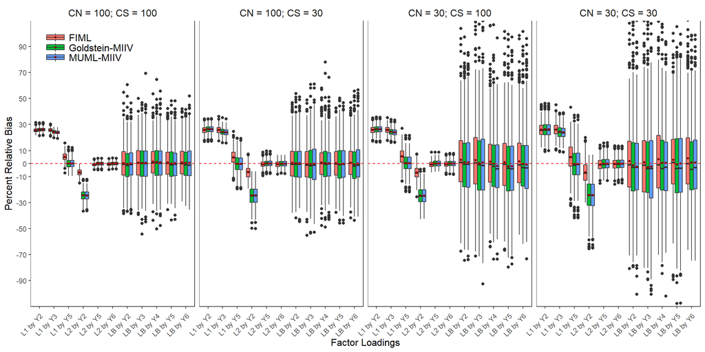

## Table 10 bias

| parameter | CN = 100; CS = 100 FIML | CN = 100; CS = 100 Gold | CN = 100; CS = 100 MUML | CN = 100; CS = 30 FIML | CN = 100; CS = 30 Gold | CN = 100; CS = 30 MUML | CN = 30; CS = 100 FIML | CN = 30; CS = 100 Gold | CN = 30; CS = 100 MUML | CN = 30; CS = 30 FIML | CN = 30; CS = 30 Gold | CN = 30; CS = 30 MUML |
| --- | --- | --- | --- | --- | --- | --- | --- | --- | --- | --- | --- | --- |
| L1 by Y2 | 25.584 | 26.032 | 26.062 | 25.841 | 26.316 | 26.344 | 25.871 | 26.277 | 26.312 | 26.075 | 26.290 | 26.349 |
| L1 by Y3 | 25.656 | 24.293 | 23.877 | 25.844 | 24.420 | 24.000 | 25.874 | 24.428 | 24.021 | 26.178 | 24.355 | 23.997 |
| L1 by Y5 | 5.134 | 0.005 | 0.003 | 4.771 | -0.180 | -0.190 | 5.359 | 0.267 | 0.286 | 5.020 | -0.448 | -0.407 |
| L2 by Y2 | -6.869 | -24.561 | -24.583 | -6.691 | -24.642 | -24.663 | -7.078 | -24.722 | -24.739 | -6.867 | -24.451 | -24.478 |
| L2 by Y5 | -0.819 | -0.089 | -0.082 | -0.599 | 0.050 | 0.050 | -0.645 | 0.058 | 0.070 | -0.789 | -0.134 | -0.093 |
| L2 by Y6 | -0.474 | -0.085 | -0.069 | -0.430 | -0.138 | -0.109 | -0.389 | -0.037 | -0.025 | -0.243 | -0.105 | -0.047 |
| LB by Y2 | 0.156 | -0.558 | -0.037 | 0.477 | 0.166 | 0.211 | 2.873 | 1.019 | 0.857 | 1.959 | -1.415 | -2.569 |
| LB by Y3 | 0.483 | 0.171 | 0.544 | -0.485 | -0.399 | -0.277 | 2.668 | 0.169 | 0.758 | 1.003 | -2.731 | -2.339 |
| LB by Y4 | 1.466 | 1.184 | 0.851 | 0.709 | 0.278 | 0.187 | 1.415 | -0.212 | -1.849 | 3.391 | 0.566 | 0.454 |
| LB by Y5 | 0.655 | 0.103 | 0.139 | 0.343 | -0.638 | -0.135 | 0.935 | -2.051 | -2.120 | 2.831 | -0.785 | -0.080 |
| LB by Y6 | 0.826 | 0.366 | 0.494 | 0.557 | -0.763 | 0.104 | 1.639 | -0.564 | -0.889 | 3.923 | 0.653 | 0.788 |

## Table 11 RMSE

| parameter | CN = 100; CS = 100 FIML | CN = 100; CS = 100 Gold | CN = 100; CS = 100 MUML | CN = 100; CS = 30 FIML | CN = 100; CS = 30 Gold | CN = 100; CS = 30 MUML | CN = 30; CS = 100 FIML | CN = 30; CS = 100 Gold | CN = 30; CS = 100 MUML | CN = 30; CS = 30 FIML | CN = 30; CS = 30 Gold | CN = 30; CS = 30 MUML |
| --- | --- | --- | --- | --- | --- | --- | --- | --- | --- | --- | --- | --- |
| L1 by Y2 | 0.205 | 0.209 | 0.209 | 0.208 | 0.212 | 0.212 | 0.208 | 0.212 | 0.212 | 0.213 | 0.215 | 0.216 |
| L1 by Y3 | 0.180 | 0.170 | 0.167 | 0.182 | 0.172 | 0.169 | 0.182 | 0.172 | 0.169 | 0.187 | 0.174 | 0.172 |
| L1 by Y5 | 0.018 | 0.011 | 0.011 | 0.023 | 0.020 | 0.020 | 0.024 | 0.020 | 0.020 | 0.037 | 0.037 | 0.037 |
| L2 by Y2 | 0.022 | 0.075 | 0.075 | 0.025 | 0.077 | 0.077 | 0.026 | 0.077 | 0.077 | 0.033 | 0.082 | 0.082 |
| L2 by Y5 | 0.013 | 0.012 | 0.012 | 0.022 | 0.021 | 0.021 | 0.020 | 0.020 | 0.020 | 0.037 | 0.038 | 0.038 |
| L2 by Y6 | 0.011 | 0.010 | 0.010 | 0.019 | 0.018 | 0.018 | 0.018 | 0.018 | 0.018 | 0.032 | 0.032 | 0.032 |
| LB by Y2 | 0.090 | 0.096 | 0.095 | 0.100 | 0.107 | 0.107 | 0.186 | 0.194 | 0.203 | 0.214 | 0.271 | 0.313 |
| LB by Y3 | 0.083 | 0.090 | 0.093 | 0.091 | 0.101 | 0.102 | 0.170 | 0.179 | 0.181 | 0.202 | 0.221 | 0.221 |
| LB by Y4 | 0.106 | 0.119 | 0.116 | 0.113 | 0.125 | 0.120 | 0.197 | 0.202 | 0.202 | 0.262 | 0.273 | 0.261 |
| LB by Y5 | 0.089 | 0.095 | 0.095 | 0.099 | 0.112 | 0.112 | 0.188 | 0.197 | 0.195 | 0.222 | 0.232 | 0.277 |
| LB by Y6 | 0.102 | 0.107 | 0.113 | 0.111 | 0.121 | 0.127 | 0.192 | 0.195 | 0.204 | 0.241 | 0.261 | 0.252 |

## Table 12 Standard Errors (Emp_sd (meanSE))

| parameter | CN = 100; CS = 100 FIML | CN = 100; CS = 100 Gold | CN = 100; CS = 100 MUML | CN = 100; CS = 30 FIML | CN = 100; CS = 30 Gold | CN = 100; CS = 30 MUML | CN = 30; CS = 100 FIML | CN = 30; CS = 100 Gold | CN = 30; CS = 100 MUML | CN = 30; CS = 30 FIML | CN = 30; CS = 30 Gold | CN = 30; CS = 30 MUML |
| --- | --- | --- | --- | --- | --- | --- | --- | --- | --- | --- | --- | --- |
| L1 by Y2 | 0.01 (0.01) | 0.01 (0.01) | 0.01 (0.01) | 0.02 (0.02) | 0.02 (0.02) | 0.02 (0.02) | 0.02 (0.02) | 0.02 (0.02) | 0.02 (0.02) | 0.04 (0.04) | 0.05 (0.03) | 0.05 (0.04) |
| L1 by Y3 | 0.01 (0.01) | 0.01 (0.01) | 0.01 (0.01) | 0.02 (0.02) | 0.02 (0.01) | 0.02 (0.02) | 0.02 (0.02) | 0.02 (0.01) | 0.02 (0.02) | 0.04 (0.04) | 0.04 (0.03) | 0.04 (0.04) |
| L1 by Y5 | 0.01 (0.01) | 0.01 (0.01) | 0.01 (0.01) | 0.02 (0.02) | 0.02 (0.01) | 0.02 (0.02) | 0.02 (0.02) | 0.02 (0.01) | 0.02 (0.02) | 0.03 (0.03) | 0.04 (0.03) | 0.04 (0.04) |
| L2 by Y2 | 0.01 (0.01) | 0.01 (0.01) | 0.01 (0.01) | 0.02 (0.01) | 0.02 (0.02) | 0.02 (0.02) | 0.01 (0.01) | 0.02 (0.02) | 0.02 (0.02) | 0.03 (0.03) | 0.04 (0.03) | 0.04 (0.04) |
| L2 by Y5 | 0.01 (0.01) | 0.01 (0.01) | 0.01 (0.01) | 0.02 (0.02) | 0.02 (0.02) | 0.02 (0.02) | 0.02 (0.02) | 0.02 (0.02) | 0.02 (0.02) | 0.04 (0.04) | 0.04 (0.03) | 0.04 (0.04) |
| L2 by Y6 | 0.01 (0.01) | 0.01 (0.01) | 0.01 (0.01) | 0.02 (0.02) | 0.02 (0.01) | 0.02 (0.02) | 0.02 (0.02) | 0.02 (0.01) | 0.02 (0.02) | 0.03 (0.03) | 0.03 (0.02) | 0.03 (0.03) |
| LB by Y2 | 0.09 (0.09) | 0.10 (0.09) | 0.09 (0.09) | 0.10 (0.10) | 0.11 (0.09) | 0.11 (0.09) | 0.19 (0.17) | 0.19 (0.17) | 0.20 (0.17) | 0.21 (0.20) | 0.27 (0.18) | 0.31 (0.18) |
| LB by Y3 | 0.08 (0.08) | 0.09 (0.09) | 0.09 (0.09) | 0.09 (0.09) | 0.10 (0.09) | 0.10 (0.09) | 0.17 (0.16) | 0.18 (0.16) | 0.18 (0.16) | 0.20 (0.18) | 0.22 (0.16) | 0.22 (0.16) |
| LB by Y4 | 0.10 (0.10) | 0.12 (0.10) | 0.12 (0.10) | 0.11 (0.12) | 0.13 (0.10) | 0.12 (0.10) | 0.20 (0.18) | 0.20 (0.18) | 0.20 (0.18) | 0.26 (0.24) | 0.27 (0.19) | 0.26 (0.19) |
| LB by Y5 | 0.09 (0.09) | 0.10 (0.09) | 0.10 (0.09) | 0.10 (0.10) | 0.11 (0.09) | 0.11 (0.09) | 0.19 (0.17) | 0.20 (0.17) | 0.19 (0.17) | 0.22 (0.21) | 0.23 (0.18) | 0.28 (0.19) |
| LB by Y6 | 0.10 (0.10) | 0.11 (0.10) | 0.11 (0.10) | 0.11 (0.11) | 0.12 (0.10) | 0.13 (0.10) | 0.19 (0.19) | 0.20 (0.18) | 0.20 (0.18) | 0.24 (0.23) | 0.26 (0.19) | 0.25 (0.19) |

# Skew/Kurtosis

There wasn’t too much effect here honestly. In future studies it might be worth pushing around a bit more. But for the time being at least we know that these are at least mildly robust to skew/kurtosis.

Results here are for cells with 100 clusters of 30. I thought that was the most interesting. CN = 100; CS = 100 was too large, CN = 30; CS = 30 was too small (still looked ok though).

## Figure 5 : Skew/Kurtosis

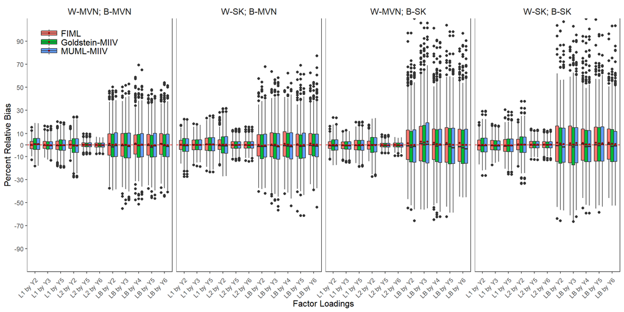

## Table 13: bias

| parameter | 0000 - MVN FIML | 0000 - MVN Gold | 0000 - MVN MUML | 0028 - btw skew FIML | 0028 - btw skew Gold | 0028 - btw skew MUML | 2800 - within skew FIML | 2800 - within skew Gold | 2800 - within skew MUML | 2828 both skew FIML | 2828 both skew Gold | 2828 both skew MUML |
| --- | --- | --- | --- | --- | --- | --- | --- | --- | --- | --- | --- | --- |
| L1 by Y2 | 0.066 | 0.778 | 0.783 | -0.130 | -0.098 | -0.100 | 0.224 | 0.107 | 0.106 | -0.149 | 0.058 | 0.047 |
| L1 by Y3 | 0.102 | -0.199 | -0.206 | -0.152 | -0.391 | -0.401 | 0.064 | 0.007 | -0.014 | -0.129 | -0.351 | -0.328 |
| L1 by Y5 | -0.279 | -0.180 | -0.190 | -0.132 | -0.092 | -0.092 | 0.559 | 0.532 | 0.562 | -0.515 | -0.437 | -0.414 |
| L2 by Y2 | 0.318 | -0.626 | -0.632 | -0.124 | -0.174 | -0.174 | 0.237 | 0.186 | 0.188 | 0.373 | 0.167 | 0.174 |
| L2 by Y5 | 0.126 | 0.050 | 0.050 | -0.084 | -0.146 | -0.139 | -0.034 | -0.114 | -0.085 | 0.340 | 0.273 | 0.287 |
| L2 by Y6 | -0.031 | -0.138 | -0.109 | -0.079 | -0.158 | -0.149 | -0.035 | -0.135 | -0.107 | 0.218 | 0.092 | 0.136 |
| LB by Y2 | 0.880 | 0.102 | 0.490 | 1.475 | -0.195 | 0.029 | -0.073 | -0.831 | -0.397 | 1.904 | 1.169 | 0.827 |
| LB by Y3 | 0.225 | 0.037 | -0.471 | 2.938 | 2.097 | 2.873 | 0.232 | 0.156 | -0.836 | 1.444 | 0.309 | 1.603 |
| LB by Y4 | 1.113 | -0.114 | 0.294 | 1.804 | 0.645 | 0.383 | 1.066 | 0.179 | -0.406 | 1.702 | 0.474 | 0.572 |
| LB by Y5 | 0.409 | -0.745 | -0.197 | 1.586 | 0.475 | 0.013 | 0.435 | -0.432 | -0.052 | 1.798 | 1.087 | 1.393 |
| LB by Y6 | 0.967 | 0.004 | -0.259 | 1.611 | 0.040 | 0.109 | 1.179 | 0.306 | 0.175 | 1.904 | 1.027 | 0.599 |

## Table 14: RMSE

| parameter | 0000 - MVN FIML | 0000 - MVN Gold | 0000 - MVN MUML | 0028 - btw skew FIML | 0028 - btw skew Gold | 0028 - btw skew MUML | 2800 - within skew FIML | 2800 - within skew Gold | 2800 - within skew MUML | 2828 both skew FIML | 2828 both skew Gold | 2828 both skew MUML |
| --- | --- | --- | --- | --- | --- | --- | --- | --- | --- | --- | --- | --- |
| L1 by Y2 | 0.035 | 0.057 | 0.057 | 0.035 | 0.054 | 0.053 | 0.047 | 0.067 | 0.067 | 0.049 | 0.072 | 0.072 |
| L1 by Y3 | 0.031 | 0.033 | 0.033 | 0.032 | 0.034 | 0.034 | 0.042 | 0.044 | 0.044 | 0.042 | 0.043 | 0.043 |
| L1 by Y5 | 0.019 | 0.020 | 0.020 | 0.018 | 0.020 | 0.020 | 0.023 | 0.025 | 0.025 | 0.023 | 0.025 | 0.025 |
| L2 by Y2 | 0.015 | 0.027 | 0.027 | 0.016 | 0.027 | 0.027 | 0.021 | 0.031 | 0.031 | 0.020 | 0.031 | 0.031 |
| L2 by Y5 | 0.021 | 0.021 | 0.021 | 0.020 | 0.021 | 0.021 | 0.033 | 0.034 | 0.034 | 0.033 | 0.033 | 0.033 |
| L2 by Y6 | 0.018 | 0.018 | 0.018 | 0.017 | 0.018 | 0.018 | 0.030 | 0.030 | 0.030 | 0.029 | 0.028 | 0.029 |
| LB by Y2 | 0.100 | 0.106 | 0.109 | 0.148 | 0.152 | 0.153 | 0.099 | 0.108 | 0.104 | 0.161 | 0.166 | 0.165 |
| LB by Y3 | 0.092 | 0.099 | 0.099 | 0.152 | 0.154 | 0.159 | 0.096 | 0.105 | 0.104 | 0.148 | 0.154 | 0.152 |
| LB by Y4 | 0.113 | 0.123 | 0.126 | 0.177 | 0.186 | 0.179 | 0.120 | 0.127 | 0.129 | 0.175 | 0.177 | 0.180 |
| LB by Y5 | 0.100 | 0.111 | 0.109 | 0.160 | 0.170 | 0.169 | 0.106 | 0.113 | 0.115 | 0.160 | 0.168 | 0.168 |
| LB by Y6 | 0.112 | 0.123 | 0.123 | 0.182 | 0.181 | 0.178 | 0.117 | 0.124 | 0.131 | 0.171 | 0.182 | 0.179 |

## Table 15: SE (Emp_sd (meanSE))

| parameter | 0000 - MVN FIML | 0000 - MVN Gold | 0000 - MVN MUML | 0028 - btw skew FIML | 0028 - btw skew Gold | 0028 - btw skew MUML | 2800 - within skew FIML | 2800 - within skew Gold | 2800 - within skew MUML | 2828 both skew FIML | 2828 both skew Gold | 2828 both skew MUML |
| --- | --- | --- | --- | --- | --- | --- | --- | --- | --- | --- | --- | --- |
| L1 by Y2 | 0.03 (0.04) | 0.06 (0.04) | 0.06 (0.06) | 0.03 (0.04) | 0.05 (0.04) | 0.05 (0.05) | 0.05 (0.05) | 0.07 (0.04) | 0.07 (0.05) | 0.05 (0.05) | 0.07 (0.04) | 0.07 (0.06) |
| L1 by Y3 | 0.03 (0.03) | 0.03 (0.02) | 0.03 (0.03) | 0.03 (0.03) | 0.03 (0.02) | 0.03 (0.03) | 0.04 (0.04) | 0.04 (0.02) | 0.04 (0.03) | 0.04 (0.04) | 0.04 (0.02) | 0.04 (0.03) |
| L1 by Y5 | 0.02 (0.02) | 0.02 (0.01) | 0.02 (0.02) | 0.02 (0.02) | 0.02 (0.01) | 0.02 (0.02) | 0.02 (0.02) | 0.03 (0.01) | 0.03 (0.02) | 0.02 (0.02) | 0.03 (0.01) | 0.03 (0.02) |
| L2 by Y2 | 0.02 (0.01) | 0.03 (0.02) | 0.03 (0.03) | 0.02 (0.01) | 0.03 (0.02) | 0.03 (0.03) | 0.02 (0.02) | 0.03 (0.02) | 0.03 (0.03) | 0.02 (0.02) | 0.03 (0.02) | 0.03 (0.03) |
| L2 by Y5 | 0.02 (0.02) | 0.02 (0.02) | 0.02 (0.02) | 0.02 (0.02) | 0.02 (0.02) | 0.02 (0.02) | 0.03 (0.03) | 0.03 (0.02) | 0.03 (0.02) | 0.03 (0.03) | 0.03 (0.02) | 0.03 (0.02) |
| L2 by Y6 | 0.02 (0.02) | 0.02 (0.01) | 0.02 (0.02) | 0.02 (0.02) | 0.02 (0.01) | 0.02 (0.02) | 0.03 (0.03) | 0.03 (0.01) | 0.03 (0.02) | 0.03 (0.03) | 0.03 (0.01) | 0.03 (0.02) |
| LB by Y2 | 0.10 (0.10) | 0.11 (0.09) | 0.11 (0.09) | 0.15 (0.14) | 0.15 (0.09) | 0.15 (0.09) | 0.10 (0.10) | 0.11 (0.09) | 0.10 (0.09) | 0.16 (0.14) | 0.17 (0.09) | 0.16 (0.09) |
| LB by Y3 | 0.09 (0.09) | 0.10 (0.09) | 0.10 (0.09) | 0.15 (0.13) | 0.15 (0.09) | 0.16 (0.09) | 0.10 (0.09) | 0.11 (0.09) | 0.10 (0.09) | 0.15 (0.13) | 0.15 (0.09) | 0.15 (0.09) |
| LB by Y4 | 0.11 (0.12) | 0.12 (0.10) | 0.13 (0.10) | 0.18 (0.16) | 0.19 (0.10) | 0.18 (0.10) | 0.12 (0.12) | 0.13 (0.10) | 0.13 (0.10) | 0.17 (0.16) | 0.18 (0.10) | 0.18 (0.10) |
| LB by Y5 | 0.10 (0.10) | 0.11 (0.09) | 0.11 (0.09) | 0.16 (0.15) | 0.17 (0.09) | 0.17 (0.09) | 0.11 (0.10) | 0.11 (0.09) | 0.11 (0.09) | 0.16 (0.14) | 0.17 (0.09) | 0.17 (0.09) |
| LB by Y6 | 0.11 (0.11) | 0.12 (0.10) | 0.12 (0.10) | 0.18 (0.16) | 0.18 (0.10) | 0.18 (0.10) | 0.12 (0.11) | 0.12 (0.10) | 0.13 (0.10) | 0.17 (0.15) | 0.18 (0.10) | 0.18 (0.10) |

# Balance/Unbalance

## Figure 6 : Unbalance

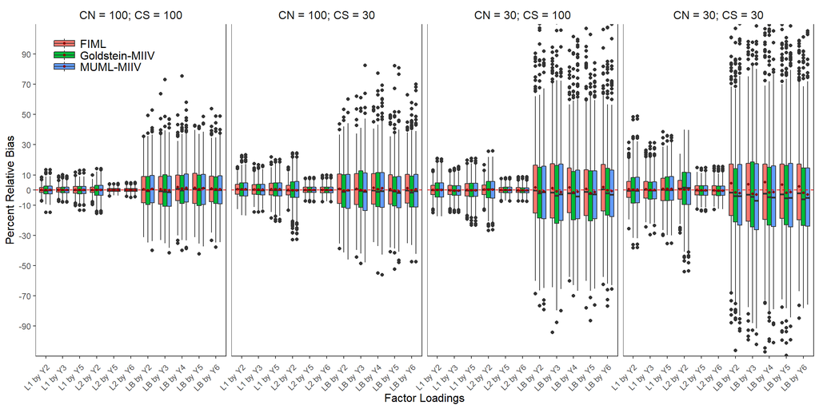

## Table 16: bias

| parameter | CN = 100; CS = 100 FIML | CN = 100; CS = 100 Gold | CN = 100; CS = 100 MUML | CN = 100; CS = 30 FIML | CN = 100; CS = 30 Gold | CN = 100; CS = 30 MUML | CN = 30; CS = 100 FIML | CN = 30; CS = 100 Gold | CN = 30; CS = 100 MUML | CN = 30; CS = 30 FIML | CN = 30; CS = 30 Gold | CN = 30; CS = 30 MUML |
| --- | --- | --- | --- | --- | --- | --- | --- | --- | --- | --- | --- | --- |
| L1 by Y2 | 0.024 | 0.068 | 0.077 | 0.411 | 0.541 | 0.539 | -0.036 | -0.009 | -0.004 | 0.374 | 0.288 | 0.315 |
| L1 by Y3 | 0.107 | 0.041 | 0.055 | 0.315 | 0.229 | 0.228 | -0.147 | -0.380 | -0.344 | 0.462 | 0.018 | 0.035 |
| L1 by Y5 | 0.022 | -0.038 | -0.033 | 0.393 | 0.380 | 0.385 | 0.021 | -0.115 | -0.113 | 0.785 | 0.720 | 0.772 |
| L2 by Y2 | 0.052 | 0.026 | 0.017 | -0.004 | -0.200 | -0.197 | 0.153 | 0.157 | 0.153 | 0.438 | 0.332 | 0.288 |
| L2 by Y5 | 0.004 | 0.004 | 0.006 | 0.092 | 0.043 | 0.060 | 0.078 | 0.065 | 0.074 | -0.057 | -0.248 | -0.189 |
| L2 by Y6 | 0.056 | 0.031 | 0.036 | 0.106 | 0.031 | 0.051 | -0.116 | -0.201 | -0.180 | -0.140 | -0.403 | -0.363 |
| LB by Y2 | 0.518 | -0.125 | 0.714 | 0.712 | -0.523 | -0.246 | 1.623 | -0.901 | -0.820 | 4.562 | -1.574 | -2.087 |
| LB by Y3 | 0.430 | 0.078 | -0.222 | 0.606 | 0.062 | -0.353 | 1.100 | -0.987 | -1.295 | 3.680 | -2.557 | -3.104 |
| LB by Y4 | 1.818 | 0.997 | 1.403 | 1.363 | 0.383 | 1.205 | 1.664 | -1.661 | -1.281 | 5.259 | -1.692 | -1.389 |
| LB by Y5 | 1.319 | 0.512 | 1.120 | 0.401 | -0.454 | -0.905 | 0.638 | -2.125 | -1.378 | 3.639 | -1.925 | -1.503 |
| LB by Y6 | 0.984 | 0.371 | 0.466 | 1.246 | -0.283 | 0.377 | 1.855 | -0.225 | -0.588 | 2.458 | -1.843 | -3.022 |

## Table 17: RMSE table

| parameter | CN = 100; CS = 100 FIML | CN = 100; CS = 100 Gold | CN = 100; CS = 100 MUML | CN = 100; CS = 30 FIML | CN = 100; CS = 30 Gold | CN = 100; CS = 30 MUML | CN = 30; CS = 100 FIML | CN = 30; CS = 100 Gold | CN = 30; CS = 100 MUML | CN = 30; CS = 30 FIML | CN = 30; CS = 30 Gold | CN = 30; CS = 30 MUML |
| --- | --- | --- | --- | --- | --- | --- | --- | --- | --- | --- | --- | --- |
| L1 by Y2 | 0.020 | 0.031 | 0.031 | 0.038 | 0.055 | 0.055 | 0.037 | 0.056 | 0.056 | 0.069 | 0.102 | 0.102 |
| L1 by Y3 | 0.017 | 0.018 | 0.018 | 0.034 | 0.036 | 0.035 | 0.033 | 0.035 | 0.035 | 0.059 | 0.063 | 0.063 |
| L1 by Y5 | 0.010 | 0.011 | 0.011 | 0.018 | 0.020 | 0.020 | 0.019 | 0.021 | 0.021 | 0.032 | 0.035 | 0.035 |
| L2 by Y2 | 0.008 | 0.014 | 0.014 | 0.014 | 0.025 | 0.025 | 0.015 | 0.025 | 0.025 | 0.027 | 0.049 | 0.049 |
| L2 by Y5 | 0.011 | 0.011 | 0.011 | 0.022 | 0.022 | 0.022 | 0.019 | 0.020 | 0.020 | 0.037 | 0.038 | 0.037 |
| L2 by Y6 | 0.010 | 0.010 | 0.010 | 0.019 | 0.019 | 0.019 | 0.016 | 0.017 | 0.017 | 0.033 | 0.033 | 0.033 |
| LB by Y2 | 0.089 | 0.095 | 0.096 | 0.100 | 0.109 | 0.116 | 0.181 | 0.188 | 0.186 | 0.547 | 0.224 | 0.233 |
| LB by Y3 | 0.084 | 0.090 | 0.089 | 0.092 | 0.102 | 0.112 | 0.175 | 0.187 | 0.176 | 0.645 | 0.211 | 0.236 |
| LB by Y4 | 0.103 | 0.112 | 0.114 | 0.121 | 0.132 | 0.141 | 0.204 | 0.205 | 0.214 | 0.629 | 0.298 | 0.291 |
| LB by Y5 | 0.095 | 0.102 | 0.101 | 0.102 | 0.113 | 0.114 | 0.180 | 0.181 | 0.185 | 0.456 | 0.239 | 0.252 |
| LB by Y6 | 0.102 | 0.108 | 0.108 | 0.114 | 0.126 | 0.134 | 0.191 | 0.212 | 0.213 | 0.396 | 0.374 | 0.255 |

## Table 18: Standard Errors (Emp_sd (meanSE))

| parameter | CN = 100; CS = 100 FIML | CN = 100; CS = 100 Gold | CN = 100; CS = 100 MUML | CN = 100; CS = 30 FIML | CN = 100; CS = 30 Gold | CN = 100; CS = 30 MUML | CN = 30; CS = 100 FIML | CN = 30; CS = 100 Gold | CN = 30; CS = 100 MUML | CN = 30; CS = 30 FIML | CN = 30; CS = 30 Gold | CN = 30; CS = 30 MUML |
| --- | --- | --- | --- | --- | --- | --- | --- | --- | --- | --- | --- | --- |
| L1 by Y2 | 0.02 (0.02) | 0.03 (0.02) | 0.03 (0.03) | 0.04 (0.04) | 0.05 (0.04) | 0.06 (0.05) | 0.04 (0.04) | 0.06 (0.04) | 0.06 (0.05) | 0.07 (0.06) | 0.10 (0.07) | 0.10 (0.10) |
| L1 by Y3 | 0.02 (0.02) | 0.02 (0.01) | 0.02 (0.02) | 0.03 (0.03) | 0.04 (0.02) | 0.04 (0.03) | 0.03 (0.03) | 0.04 (0.02) | 0.03 (0.03) | 0.06 (0.06) | 0.06 (0.04) | 0.06 (0.06) |
| L1 by Y5 | 0.01 (0.01) | 0.01 (0.01) | 0.01 (0.01) | 0.02 (0.02) | 0.02 (0.01) | 0.02 (0.02) | 0.02 (0.02) | 0.02 (0.01) | 0.02 (0.02) | 0.03 (0.03) | 0.03 (0.03) | 0.03 (0.04) |
| L2 by Y2 | 0.01 (0.01) | 0.01 (0.01) | 0.01 (0.01) | 0.01 (0.01) | 0.02 (0.02) | 0.02 (0.03) | 0.01 (0.01) | 0.02 (0.02) | 0.03 (0.03) | 0.03 (0.03) | 0.05 (0.04) | 0.05 (0.05) |
| L2 by Y5 | 0.01 (0.01) | 0.01 (0.01) | 0.01 (0.01) | 0.02 (0.02) | 0.02 (0.02) | 0.02 (0.02) | 0.02 (0.02) | 0.02 (0.02) | 0.02 (0.02) | 0.04 (0.04) | 0.04 (0.03) | 0.04 (0.04) |
| L2 by Y6 | 0.01 (0.01) | 0.01 (0.01) | 0.01 (0.01) | 0.02 (0.02) | 0.02 (0.01) | 0.02 (0.02) | 0.02 (0.02) | 0.02 (0.01) | 0.02 (0.02) | 0.03 (0.03) | 0.03 (0.02) | 0.03 (0.03) |
| LB by Y2 | 0.09 (0.09) | 0.10 (0.09) | 0.10 (0.09) | 0.10 (0.10) | 0.11 (0.09) | 0.12 (0.09) | 0.18 (0.17) | 0.19 (0.17) | 0.19 (0.17) | 0.55 (0.33) | 0.22 (0.17) | 0.23 (0.17) |
| LB by Y3 | 0.08 (0.08) | 0.09 (0.09) | 0.09 (0.09) | 0.09 (0.10) | 0.10 (0.09) | 0.11 (0.09) | 0.18 (0.16) | 0.19 (0.16) | 0.18 (0.16) | 0.64 (0.35) | 0.21 (0.16) | 0.24 (0.16) |
| LB by Y4 | 0.10 (0.10) | 0.11 (0.10) | 0.11 (0.10) | 0.12 (0.12) | 0.13 (0.10) | 0.14 (0.10) | 0.20 (0.19) | 0.20 (0.18) | 0.21 (0.18) | 0.63 (0.40) | 0.30 (0.18) | 0.29 (0.20) |
| LB by Y5 | 0.09 (0.09) | 0.10 (0.09) | 0.10 (0.09) | 0.10 (0.11) | 0.11 (0.09) | 0.11 (0.09) | 0.18 (0.18) | 0.18 (0.17) | 0.18 (0.17) | 0.46 (0.31) | 0.24 (0.17) | 0.25 (0.17) |
| LB by Y6 | 0.10 (0.10) | 0.11 (0.10) | 0.11 (0.10) | 0.11 (0.12) | 0.13 (0.10) | 0.13 (0.10) | 0.19 (0.18) | 0.21 (0.18) | 0.21 (0.18) | 0.40 (0.32) | 0.37 (0.20) | 0.25 (0.18) |

# Figure 7: Sargan’s test True Model

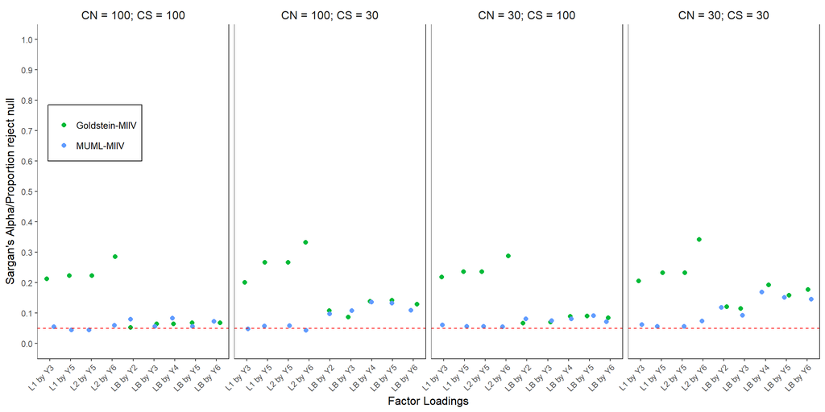

# Figure 8: Sargan’s Misspecified #1

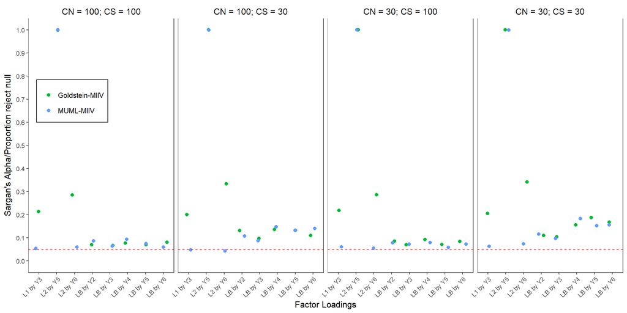

# Figure 9: Sargan’s test Misspecified #2

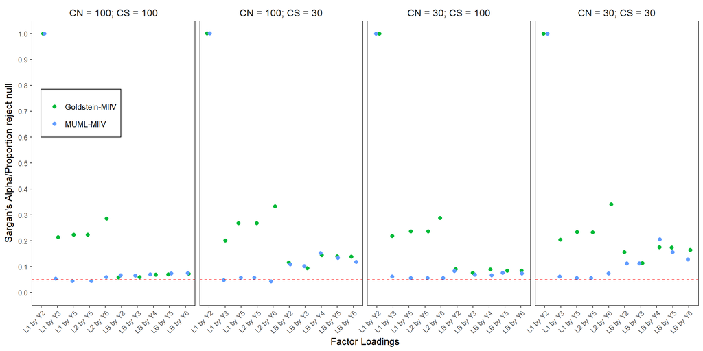

# Figure 10: Sargan’s test Misspecified #3

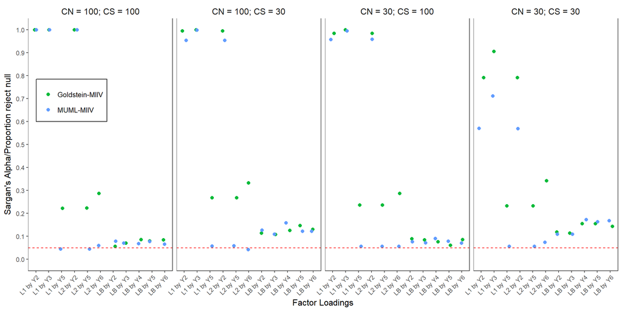

# Figure: Sargan’s test for skew/kurtosis

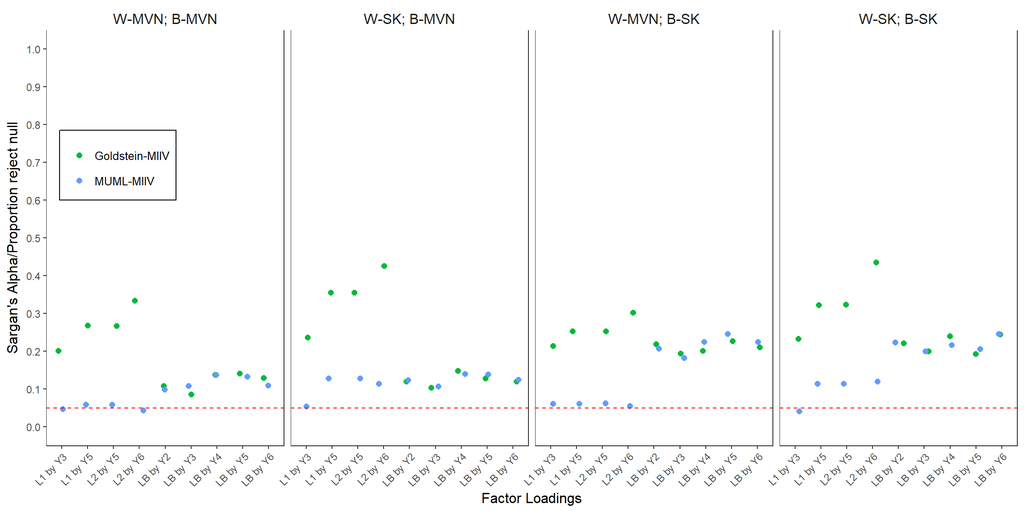

# Figure: Sargan’s test for Unbalanced

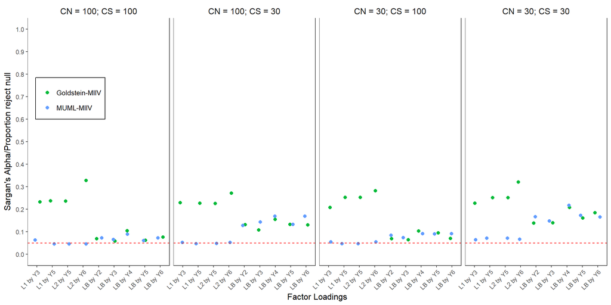

# adding the variance covariance parameters

I only did this for the balance, truemodel, no skew/kurtosis conditions

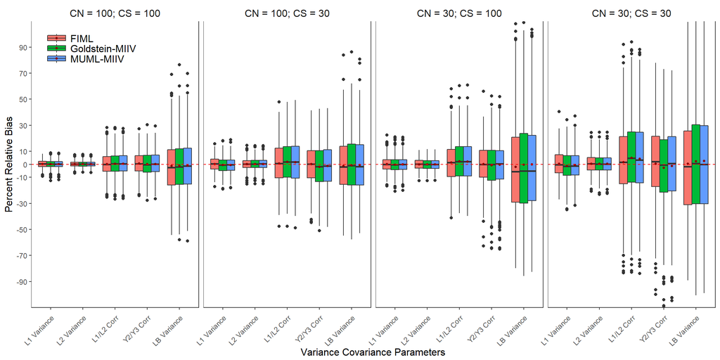